# Regression part I

## Why regression?

The covariance and correlation tell us about the “relationship” between variables, but we want to know more:

- What is the **prediction** of $y$ given a value of $x$?
- How does the prediction of $y$ change when $x$ changes?
- What is the **causal effect** of $x$ on $y$?

The last two aren’t always the same thing, we’ll have a lot to say about when a statistical relationship can also be interpreted as a causal effect

## The population regression line

Let’s assume that the equation for $y$ is
$$y_i = \alpha + \beta x_i + \varepsilon_i$$

In this equation,

- $\alpha$ is the **population intercept**. This is the value that $y$ would take if $x$ and $\varepsilon$ were both zero
- $\beta$ is the **population slope**. We interpret this as the **causal effect** of $x$ on $y$
- $\varepsilon$ is the **error term**. This reflects the fact that $y$ is random, and affected by things other than $x$

$\alpha$ and $\beta$ are the **population** intercept and slope

We can think of these as the intercept/slope in the true equation that affects the whole population

Since we don’t know the whole population, we want to come up with **estimate** of $\alpha$ and $\beta$ based on our particular sample

## Estimating the regression line

The population line is
$$y_i = \alpha + \beta x_i + \varepsilon_i$$
and we want to use our sample to estimate $\alpha$ and $\beta$

Our estimated line will take the form
$$\widehat{y}_i = a + b x_i$$

$a$ will be our estimate of $\alpha$ and $b$ will be our estimate of $\beta$

The “hat” indicates that our line will give us a **prediction** of $y_i$ and not the actual value

If we have estimates $a$ and $b$, the **residual** for our estimated line is the difference between the true value of $y_i$ and our prediction $\widehat{y}_i$:
$$e_i = y_i - \widehat{y}_i$$

In general, we want our residuals to be as small as possible

However, we will have $n$ residuals, one for each observation, so we need some way of making “all” of the residuals small

We could try to make the *sum* of the residuals as small as possible

However, it turns out that this doesn’t work:

```r
x <- c(0, 1)
y <- c(0, 1)
plot(x,y, type="b")
y1 <- c(1,0)
lines(x,y1, type="b", lty=2)
```

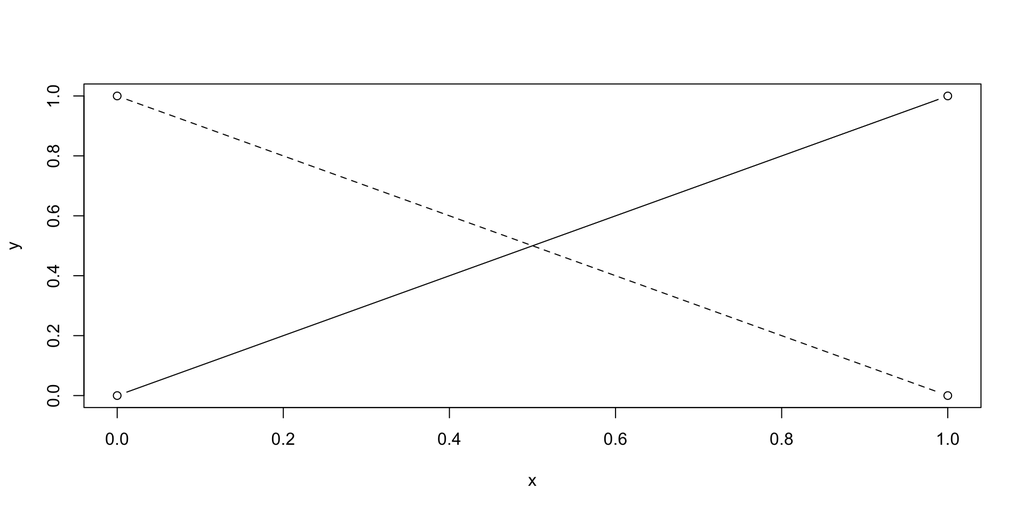

The problem is that large *negative* residuals cancel out with large *positive* residuals, so that even a bad line can have the residuals sum to zero

Instead, we will try to minimize the sum of *squared* residuals

We will choose our estimates $a$ and $b$ to be the values that minimize
$$\begin{aligned}
\sum_{i=1}^n e_i^2 &= \sum_{i=1}^n (y_i - \widehat{y}_i)^2 \\
&= \sum_{i=1}^n (y_i - a - b x_i)^2
\end{aligned}$$

Finding the values of $a$ and $b$ that minimize the sum of squared residuals is a standard calculus problem

To solve it, we’ll make a simplification: Assume that $y$ and $x$ are in *deviations-from-means* form (i.e., instead of $y$ we have $y-\bar y$, and similarly for $x$)

Our model implies that the population mean of $y$ is

$$\bar y = \alpha + \beta \bar x + \bar \varepsilon$$
So

$$\begin{aligned} y_i - \bar y &= (\alpha + \beta x_i + \varepsilon_i) - (\alpha + \beta \bar x + \bar \varepsilon) \\
& = \beta (x_i - \bar x) + (\varepsilon_i - \bar \varepsilon)
\end{aligned}$$

Therefore, if $y$, $x$ and $\varepsilon$ are *already* in deviations-from-mean form, we can drop the constant term and write the model as

$$y_i = \beta x_i + \varepsilon_i$$

(Technically, we should use different notation for the original variables and their deviations from means. Here, we are implicitly saying that $y_i$ really represents $y_i - \bar y$)

Now we only need to find the value of $b$ that minimizes
$$\sum_{i=1}^n e_i^2 = \sum_{i=1}^n (y_i - b x_i)^2$$

Recall from calculus that to minimize a function, we take the derivative with respect to the variable (which is $b$ in this case), and set it equal to zero

Also recall that the derivative of a sum is the sum of the derivatives

The derivative of one term in the sum with is just
$$2 (y_i - b x_i)(-x_i)$$

So the derivative of the SSR is
$$(-2) \sum_{i=1}^n (y_i - b x_i)x_i$$

At the minimum, this must equal zero:
$$(-2) \sum_{i=1}^n (y_i - b x_i)x_i = 0$$

We can divide both sides by $-2$ to get
$$\sum_{i=1}^n (y_i - b x_i)x_i = 0$$

We can rewrite this as

$$\sum_i y_i x_i - b \sum_i x_i^2 = 0$$

Solving for $b$:
$$b = \frac{\sum_{i=1}^n y_i x_i}{\sum_{i=1}^n x_i^2}$$

A technical aside: To make sure we’ve found the minimum of the SSR, we also need to make sure that its *second* derivative is *positive*

Since the first derivative is $(-2) \sum_{i=1}^n (y_i - b x_i)x_i$, the second derivative is

$$2 \sum_i x_i^2 > 0,$$

so it’s all good

What happens if $y$ and $x$ are not in deviations-from-means form?

We can simply replace them with deviations from means in the equation for $b$:

$$b = \frac{\sum_{i=1}^n (x_i - \bar x)(y_i - \bar y)}{\sum_{i=1}^n (x_i - \bar x)^2}$$

To find the constant term, recall that $e_i = y_i - \widehat{y}_i$, or after rearranging

$$y_i = \widehat{y}_i + e_i$$
If $x$ and $y$ are in deviations form, $\hat y = bx$, so this is just

$$y_i = b x_i + e_i$$

If $x$ and $y$ are not in deviations form, we can replace them with their deviations to get

$$y_i - \bar y = b (x_i - \bar x) + e_i$$

or, rearranging,

$$y_i = \underbrace{\overbrace{(\bar y - b \bar x)}^{\text{Constant}} + b x_i}_{\widehat{y}_i} + e_i$$

Therefore the constant term in $\hat y$ is $\bar y - b \bar x$, so

$$a = \bar y - b \bar x$$

To summarize, if we express $x$ and $y$ in their original forms, we have

$$\begin{aligned}
b & = \frac{\sum_i (y_i - \bar y)(x_i - \bar x)}{\sum_i (x_i - \bar x)^2} \\
a &= \bar{y} - b \bar x
\end{aligned}$$

$a$ and $b$ are the **Ordinary Least Squares (OLS)** estimates of $\alpha$ and $\beta$

## Properties of the residuals

Let’s quickly discuss two properties of the OLS residuals

**Property 1.** $\bar{e}=0$

Why? Using the “original” form of $y$ and $x$ (which is simpler than deviations-from-means form here)

$$\begin{aligned}
e_i &= y_i - \widehat{y}_i \\
&= y_i - a - b x_i \\
& = y_i - (\bar y - b \bar x) - b x_i \\
& = (y_i - \bar y) - b(x_i - \bar x)
\end{aligned}$$

Therefore, averaging both sides gives

$$\bar e = (\bar y - \bar y) - b (\bar x - \bar x) = 0$$

Since $\bar e = (\sum_i e_i)/n$, this also implies that the residuals sum to zero

**Property 2.** $Cov(x,e)=0$

Recall that, taking the derivative of the SSR, we found
$$\sum_i (y_i - bx_i) x_i = 0$$
But $y_i - bx_i=e_i$ so this implies that $\sum_i e_i x_i=0$

But
$$Cov(x_i, e_i) = \frac{\sum_i (x_i - \bar x)(e_i - \bar e)}{n-1}
= \frac{\sum_i x_i e_i}{n-1} = 0$$
where we have used the fact that $x$ (which is in deviations-from-means form) and $e$ have mean zero

## Illustrating residual properties

The residual properties come from the fact that $a$ and $b$ are the “best” estimates of $\alpha$ and $\beta$ (the ones that minimize the SSR)

To illustrate the first property, consider what it would mean if $\bar e \ne 0$:

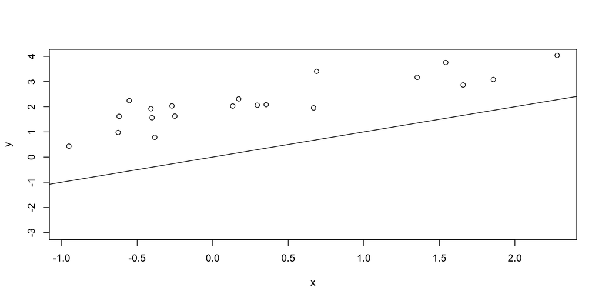

In the graph, $e_i = y _i - \hat{y}_i$ is always positive, so $\bar e \ne 0$

In this case, we could obviously improve our line by moving it up a little bit

The first residual property says that, with a regression, this can’t happen

Now consider the following situation

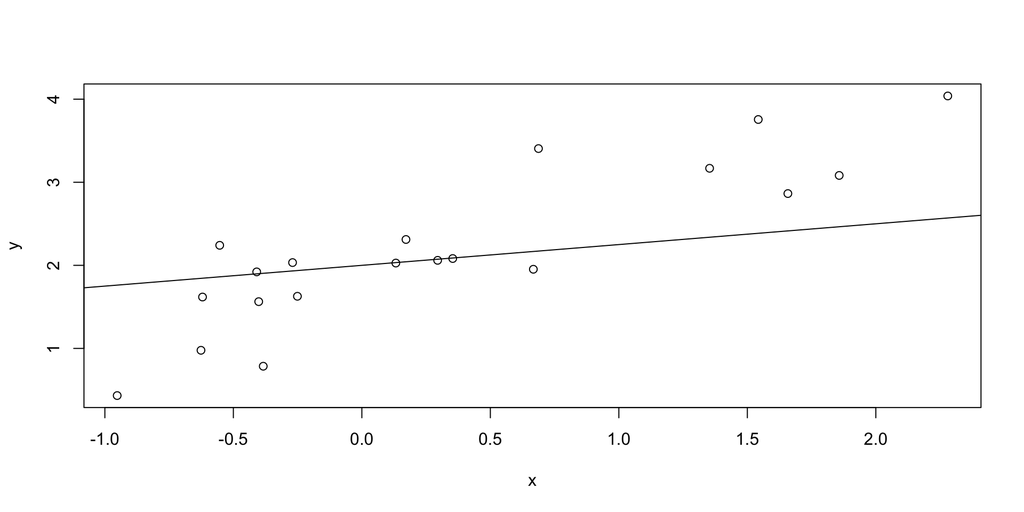

Here, the slope of the line is too flat

We could obviously improve our line by rotating it a little bit

The second residual property says that, with a regression, this can’t happen

## Interpreting the regression line

Our estimated line is

$$\widehat{y}_i = a + b x_i$$

We interpret the estimated slope coefficient $b$ as

$$b = \frac{\Delta \widehat{y}}{\Delta x}$$

In words, $b$ tells us how much our *prediction* of $y$ will change when $x$ increases by one unit

We also want to interpret $b$ as our estimate of $\beta$, the *population* slope coefficient

However, in order to do that, certain assumptions must be satisfied

We will have more to say about this in the next section of the class

But we can always interpret $b$ as the relationship between $x$ and $\widehat y$

## Regression in action

E.g.:

```r
library(tidyverse)
gril <- read_csv("griliches.csv")
gril$wage <- exp(gril$lw)
model <- lm(wage ~ s, data=gril)
summary(model)
```

```
Call:
lm(formula = wage ~ s, data = gril)

Residuals:
    Min      1Q  Median      3Q     Max
-344.94  -84.91  -20.59   60.90  676.12

Coefficients:
            Estimate Std. Error t value Pr(>|t|)
(Intercept) -125.295     28.458  -4.403 1.22e-05 ***
s             33.511      2.094  16.002  < 2e-16 ***
---
Signif. codes:  0 '***' 0.001 '**' 0.01 '*' 0.05 '.' 0.1 ' ' 1

Residual standard error: 128.6 on 756 degrees of freedom
Multiple R-squared:  0.253, Adjusted R-squared:  0.252
F-statistic: 256.1 on 1 and 756 DF,  p-value: < 2.2e-16
```

Let’s run the regression “manually”:

```r
wbar <- mean(gril$wage)
wdev <- gril$wage - wbar
sbar <- mean(gril$s)
sdev <- gril$s - sbar
b <- sum(wdev*sdev)/sum(sdev^2)
b
```

```
[1] 33.51068
```

```r
a <- wbar - b*sbar
a
```

```
[1] -125.295
```

It works! In general, we still want to use the built-in function, because it does more for us and things get complicated with more variables

Our estimated regression line is
$$\widehat{wage}_i = -125.3 + 33.5 * school$$

Graphically:

```r
plot(gril$s, model$fitted.values, type="b")
```

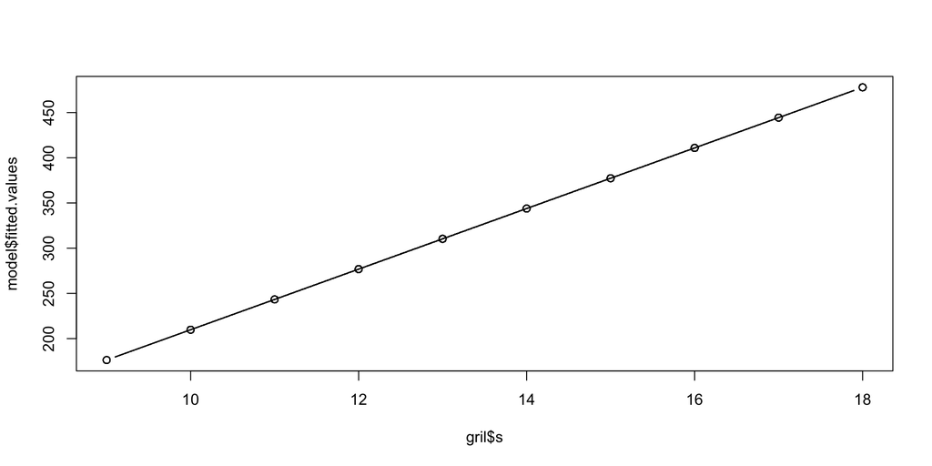

The intercept of -125.3 means that for someone with no schooling, the wage sill be -125.3 (recall that in these data, wages are measured in cents)

This sounds ridiculous, since nobody can have a negative wage

However, nobody has zero schooling:

```r
summary(gril$s)
```

```
   Min. 1st Qu.  Median    Mean 3rd Qu.    Max.
   9.00   12.00   12.00   13.41   16.00   18.00
```

The smallest amount of schooling in the sample is 9 years

The predicted value for someone with 9 years of schooling is
$$\widehat{wage}_i \big|_{s=9} = -125.3 + 33.5*9 = 176.2$$

Since
$$\widehat{wage}_i = -125.3 + 33.5 * school,$$
the effect of an increase in schooling on the predicted wage is
$$\frac{\Delta \widehat{wage}_i}{\Delta s} = 33.5$$

We interpret this to mean that *for every additional unit of schooling, the wage is predicted to increase by 33.5 cents*

## Relationship to covariance and correlation

The form of the OLS estimator of the slope coefficient $\beta$ that we have seen is probably the most useful

However, it is also related to both the sample covariance and correlation

$$\begin{aligned}
b &= \frac{\sum_i (x_i - \bar x)(y_i - \bar y)}{\sum_i (x_i - \bar x)^2}
= \frac{\frac{1}{n-1}\sum_i (x_i - \bar x)(y_i - \bar y)}
{\frac{1}{n-1}\sum_i (x_i - \bar x)^2} \\
&= \frac{Cov(x, y)}{Var(x)}
\end{aligned}$$

Also,

$$\begin{aligned}
b &= \frac{Cov(x, y)}{Var(x)} = \frac{Cov(x, y)}{sd(x)^2} \\
&= \frac{Cov(x,y)}{sd(x)^2} \cdot \frac{sd(y)}{sd(y)}
= \frac{Cov(x,y)}{sd(x) sd(y)} \cdot \frac{sd(y)}{sd(x)}\\
&= Corr(x,y) \cdot \frac{sd(y)}{sd(x)}
\end{aligned}$$

## “Goodness of fit”

The sample variance of $y$ is
$$Var(y) = \frac{\sum_i (y_i -\bar y)^2}{n-1}$$

We can think of the numerator of this as the “total variation” in $y$

When we run a regression, we are using $x$ to predict $y$

To assess how good a job our regression does of predicting $y$, we might want to compare how much more of the variation in $y$ our regression explains than if we simply used the mean $\bar y$ as our predictor

To do this, let’s assume $y$ is already in deviation-from-mean form, and write

$$y_i = (y_i - \hat{y}_i) + \hat{y_i}$$

So that the total variation $\sum y^2$ in $y$ becomes

$$\sum_i y_i^2 = \sum_i (y_i - \hat{y}_i)^2 + \sum_i \hat{y}_i^2
+ 2 \sum_i (y_i - \hat{y}_i) \hat{y}_i$$

Using residual properties, the last term is actually just (ignoring the 2)

$$\sum_i e_i (b x_i) = b \sum_i e_i x_i = 0$$

So the total variation in $y$ becomes

$$\sum_i y_i^2 = \sum_i (y_i - \hat{y}_i)^2 + \sum_i \hat{y}_i^2
= \sum_i e_i^2 + b^2 \sum_i x_i^2$$

Now, if we convert back to non-deviations form, we have

$$\sum_i (y_i - \bar y)^2 = \sum_i b^2 (x_i - \bar x)^2 + \sum_i e_i^2$$

Rearranging, we can divide the total variation in $y$ into the part that is explained by the regression and the unexplained part:

$$1 = \frac{b^2 \sum_i (x_i - \bar x)^2}{\sum_i (y_i - \bar y)^2} +
\frac{\sum_i e_i^2}{\sum_i (y_i - \bar y)^2}$$

The $R^2$ is the *fraction of the total variation in* $y$ explained by the regression (or by $x$):
$$R^2 = \frac{b^2 \sum_i (x_i - \bar x)^2}{\sum_i (y_i - \bar y)^2}
= 1 - \frac{\sum_i e_i^2}{\sum_i (y_i - \bar y)^2}$$

We usually use whichever form is easiest to work with

This gives us a sense of how good a job our regression does of “explaining” $y$ (how much better we do than if we just predicted $y$ using $\bar y$)

Don’t put too much emphasis on it. We’re usually interested in knowing whether $x$ affects $y$, and this can be true even if $x$ only explains a small fraction of the variation in $y$

Since the $R^2$ is the fraction of the variation in $y$ explained by $x$, it is always between zero and one

An $R^2$ of zero means that the regression doesn’t explain $y$ at all (so $b=0$):

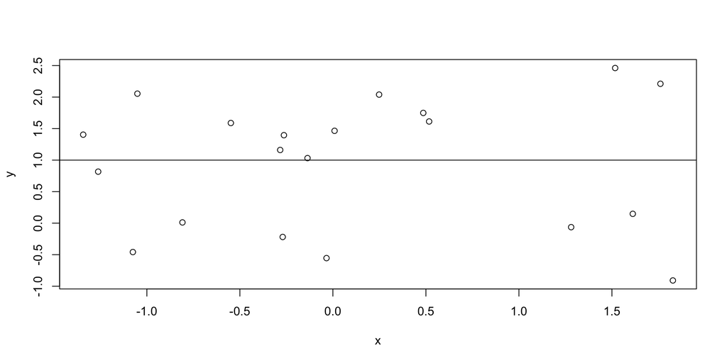

An $R^2$ of 1 means that the regression perfectly predicts $y$, so that all of the residuals are zero:

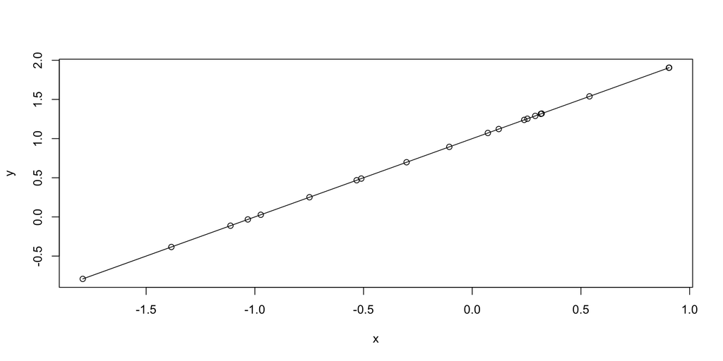

E.g.: Let’s revisit our wage model and calculate the $R^2$

```r
ss.total <- sum((gril$wage - mean(gril$wage))^2)
ss.s <- sum((gril$s - mean(gril$s))^2)
ss.e <- sum(model$residuals^2)
1 - ss.e/ss.total # version 1
```

```
[1] 0.2530168
```

```r
model$coef[2]^2 * ss.s/ss.total # version 2
```

```
        s
0.2530168
```

Fortunately, R automatically reports this for us, so we don’t have to calculate it manually every time

```r
summary(model)
```

```
Call:
lm(formula = wage ~ s, data = gril)

Residuals:
    Min      1Q  Median      3Q     Max
-344.94  -84.91  -20.59   60.90  676.12

Coefficients:
            Estimate Std. Error t value Pr(>|t|)
(Intercept) -125.295     28.458  -4.403 1.22e-05 ***
s             33.511      2.094  16.002  < 2e-16 ***
---
Signif. codes:  0 '***' 0.001 '**' 0.01 '*' 0.05 '.' 0.1 ' ' 1

Residual standard error: 128.6 on 756 degrees of freedom
Multiple R-squared:  0.253, Adjusted R-squared:  0.252
F-statistic: 256.1 on 1 and 756 DF,  p-value: < 2.2e-16
```

In the wages example, $R^2 \approx .25$, which means that education explains roughly 1/4 of the variation in $y$

Not bad, but while this is informative, we’re more interested in understanding how education affects wages (more on this in the next section)